# Fall 2018 IE 451 Applied Data Analysis

## Question 12

This problem involves writing functions.

### Part a

Write a function, Power(), that prints out the result of raising 2 to the 3rd power. In other words, your function should compute $2^3$ and print out the results.

```r
Power <- function() {
  print(2^3)
}
Power()
```

```
## [1] 8
```

### Part b

Create a new function, Power2(), that allows you to pass any two numbers, x and a, and prints out the value of x^a.

```r
Power2 <- function(x,a) {
  print(x^a)
}
Power2(3,8)
```

```
## [1] 6561
```

### Part c

Using the Power2() function that you just wrote, compute $10^3$, $8^{17}$, and $131^3$.

```r
Power2(10,3)
```

```
## [1] 1000
```

```r
Power2(8,17)
```

```
## [1] 2.2518e+15
```

```r
Power2(131,3)
```

```
## [1] 2248091
```

### Part d

Now create a new function, Power3(), that actually returns the result x^a as an R object, rather than simply printing it to the screen.

```r
Power3 <- function(x,a) {
  return(x^a)
}
Power3(3,8)
```

```
## [1] 6561
```

### Part e

Now using the Power3() function, create a plot of $f(x) = x^2$. The x-axis should display a range of integers from 1 to 10, and the y-axis should display $x^2$. Label the axes appropriately, and use an appropriate title for the figure. Consider displaying either the x-axis, the y-axis, or both on the log-scale. You can do this by using log=‘‘x’’, log=‘‘y’’, or log=‘‘xy’’ as arguments to the plot() function.

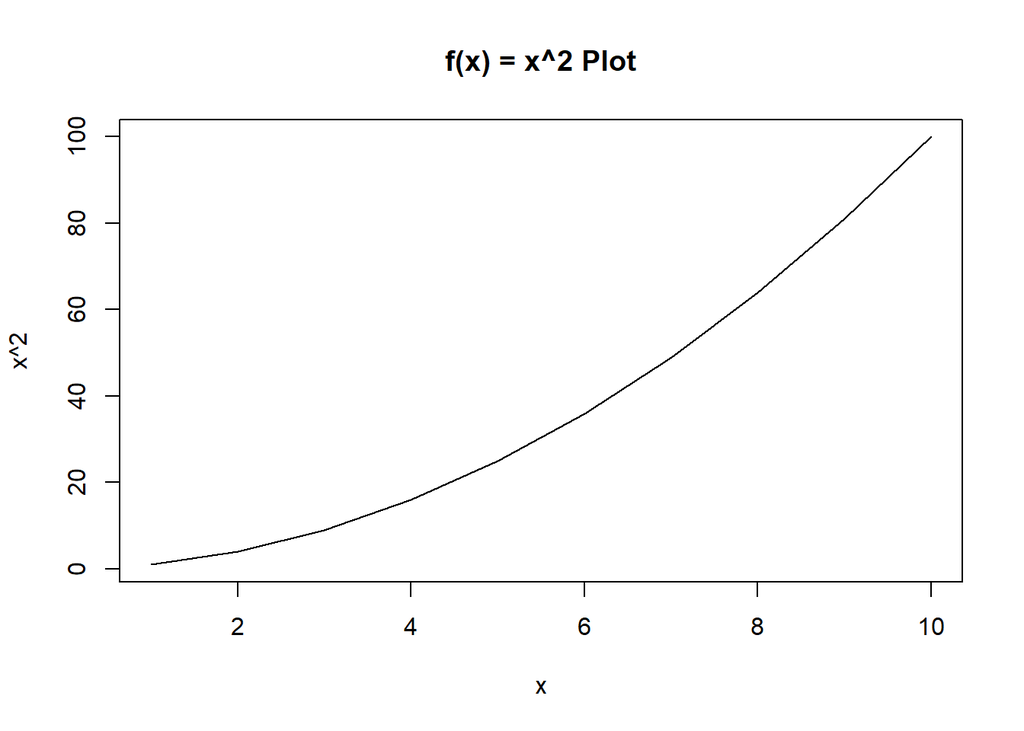

Figure 7: Using Power3() for plots

```r
x <- 1:10
y <- Power3(x,2)
plot(x,y, main = "f(x) = x^2 Plot",xlab = "x", ylab = "x^2", type = "l" )
```

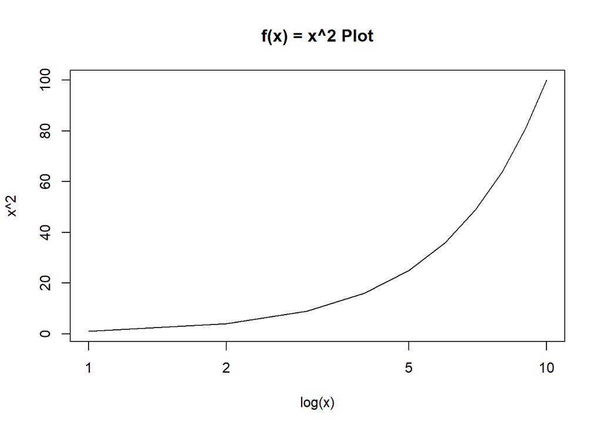

Figure 8: Using Power3() for plots

```r
plot(x,y, main = "f(x) = x^2 Plot",xlab = "log(x)", ylab = "x^2", type = "l", log="x" )
```

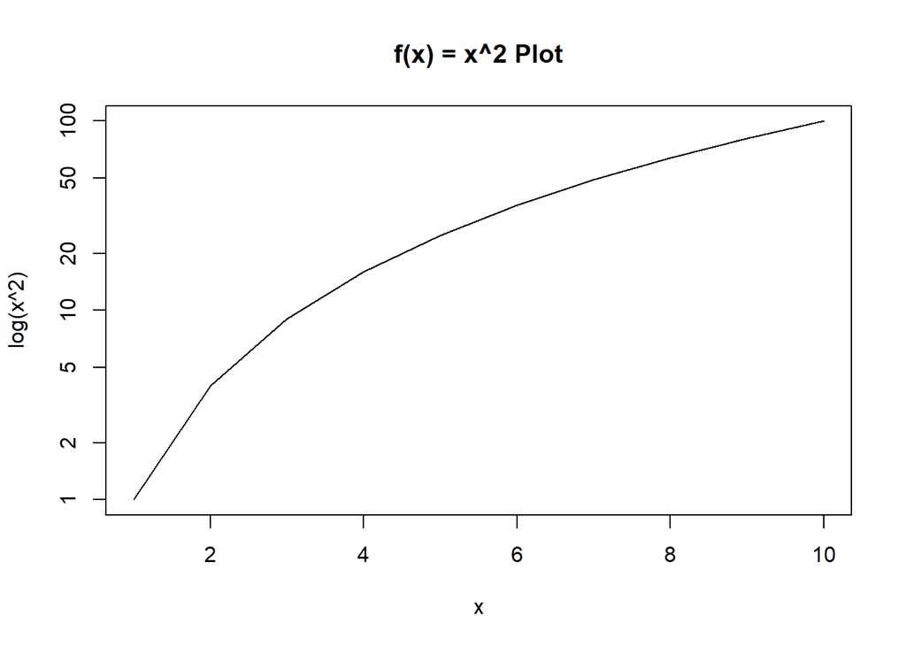

Figure 9: Using Power3() for plots

```r
plot(x,y, main = "f(x) = x^2 Plot",xlab = "x", ylab = "log(x^2)", type = "l", log="y" )
```

### Part f

Create a function, PlotPower(), that allows you to create a plot of x against x^a for a fixed a and for a range of values of x.

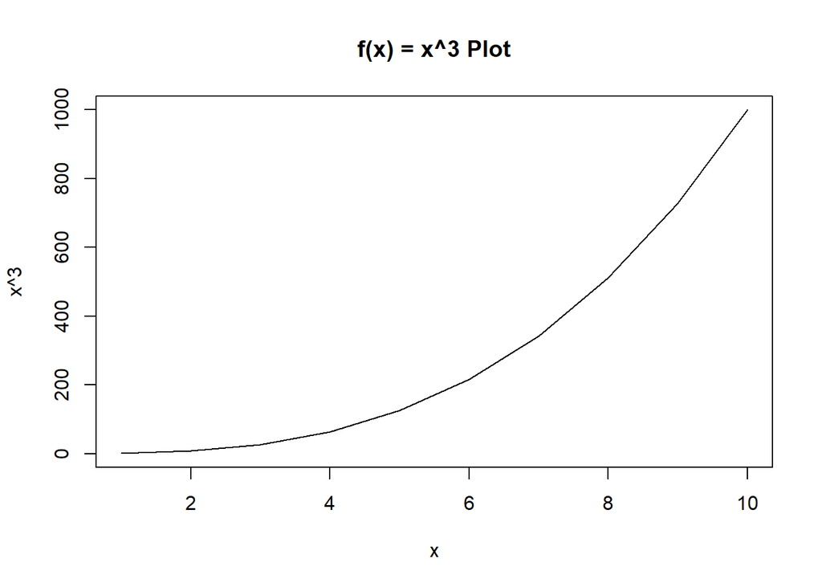

Figure 10: Using Power3() for plots

```r
PlotPower <- function(x,a) {
  plot(x, Power3(x,a), main = paste0("f(x) = x^",a," Plot"), xlab = "x", ylab = paste0("x^",a), type = "l")
}
PlotPower(1:10,3)
```